# portfolio-var-nb

Risk Simulation · Portfolio Notebook

Quantifying Portfolio Risk with Monte Carlo NPV and Value-at-Risk

**Author:** Oscar D. Nava Quintero · [caelusbellum.github.io](https://caelusbellum.github.io/)  
**Course:** AD616 — Enterprise Risk Analytics, Boston University Metropolitan College  
**Program:** MS in Applied Business Analytics  
**Source:** AD616 Assignment 2 · original coursework; datasets and problem statements are anonymized or synthetic  
**Language / stack:** Python (NumPy, SciPy, pandas, Matplotlib), Jupyter

Shared as a portfolio artifact. Not intended for reuse as academic submission. © Oscar D. Nava Quintero.

# AD616 Assignment 2

**Oscar Quintero**  
ERA616 – Simulation & Risk Analysis  
Date: May 2026

## Question 1

### Question 1a: Central Limit Theorem Demonstration

The **Central Limit Theorem (CLT)** states that the sum (or average) of a large number of independent random variables will be approximately normally distributed, regardless of the original distribution — as long as the variables have finite mean and variance. Using the Monte Carlo simulation, we will demonstrate the CLT.

- 10,000 trials
- 100 (sum of 100 uniform random variables)
  - min=0
  - max=1
- Variance of the uniform distribution is 1/12.

**Provide**:

- A histogram of the results of the MC simulation
  - **Include** a density plot of a normal distribution with the appropriate mean and standard deviation
  - **Include** the mean and standard deviation of the Monte Carlo simulation.

> **Note!** Before coding, calculate the theoretical mean and standard deviation analytically. Simulation results should closely match theory.

#### Probability Density Function (PDF) of the Normal Distribution

$$ f(x) = \frac{1}{\sigma\sqrt{2\pi}} \exp\left( -\frac{(x - \mu)^2}{2\sigma^2} \right) $$

where $\mu$ is the mean and $\sigma$ is the standard deviation.

The expected mean of the sum of 100 uniform(0,1) variables is 100 * 0.5 = 50, and the expected standard deviation is sqrt(100 * (1/12)) ≈ 2.89 [*Square root of the variance*]. Histogram should center around 50.

For the sum $S = X_1 + X_2 + \dots + X_{100}$ where each $X_i \sim \text{Uniform}(0,1)$:

$$ \mu_S = 100 \times 0.5 = 50, \qquad \sigma_S = \sqrt{100 \times \frac{1}{12}} \approx 2.89 $$

**Figure 1** demonstrates the Central Limit Theorem with Histogram and a Normal Density Overlay.

The simulated histogram will show a prominent bell shape centered near 50. **(Bars/Bins in Figure 1)** Overlaying the normal density curve $\mathcal{N}(50, 2.89^2)$ provides an excellent visual match. **(Bell-shaped Line in Figure 1)**

The calculated mean and standard deviation from the simulation *should* closely agree with the theoretical values, that will demonstrate the **Central Limit Theorem**.

```
=== CENTRAL LIMIT THEOREM RESULTS ===
```

|  | Statistic | Value |
| --- | --- | --- |
| 0 | Number of Trials | 10000.0000 |
| 1 | Expected Mean (Normal PDF) | 50.0000 |
| 2 | Simulated Mean | 50.0334 |
| 3 | Expected Std Dev (Normal PDF) | 2.8868 |
| 4 | Simulated Std Dev | 2.9137 |

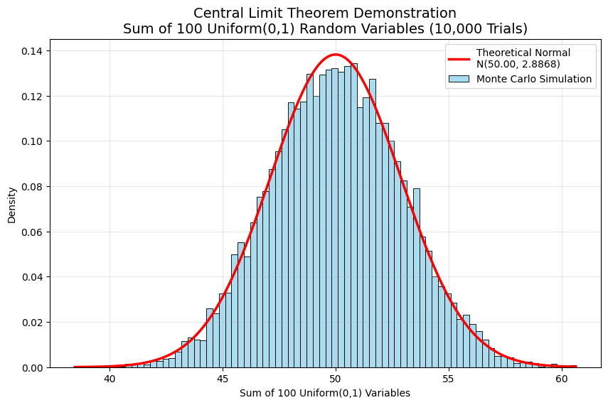

```python
import numpy as np
import matplotlib.pyplot as plt
import seaborn as sns
from scipy.stats import norm
import pandas as pd

# ====================== CENTRAL LIMIT THEOREM DEMO ======================
np.random.seed(42)
n_trials = 10_000
n_variables = 100

# Monte Carlo Simulation
sums = np.random.uniform(0, 1, size=(n_trials, n_variables)).sum(axis=1)

# Theoretical values
theoretical_mean = n_variables * 0.5                    # E[U(0,1)] = 0.5
theoretical_var = n_variables * (1/12)                  # Var(U(0,1)) = 1/12
theoretical_std = np.sqrt(theoretical_var)

# Simulation results
sim_mean = sums.mean()
sim_std = sums.std()

# ====================== RESULTS TABLE ======================
data = {
    'Statistic': [
        'Number of Trials',
        'Expected Mean (Normal PDF)',
        'Simulated Mean',
        'Expected Std Dev (Normal PDF)',
        'Simulated Std Dev'
    ],
    'Value': [
        n_trials,
        round(theoretical_mean, 4),
        round(sim_mean, 4),
        round(theoretical_std, 4),
        round(sim_std, 4)
    ]
}

df_results = pd.DataFrame(data)

print("=== CENTRAL LIMIT THEOREM RESULTS ===")
display(df_results)

# ====================== PLOT ======================
plt.figure(figsize=(10, 6))

sns.histplot(sums, bins=80, kde=False, color='skyblue',
             edgecolor='black', alpha=0.7, stat="density", label="Monte Carlo Simulation")

x = np.linspace(sums.min(), sums.max(), 500)
plt.plot(x, norm.pdf(x, loc=theoretical_mean, scale=theoretical_std),
         color='red', linewidth=2.5,
         label=f'Theoretical Normal\nN({theoretical_mean:.2f}, {theoretical_std:.4f})')

plt.title('Central Limit Theorem Demonstration\nSum of 100 Uniform(0,1) Random Variables (10,000 Trials)',
          fontsize=14)
plt.xlabel('Sum of 100 Uniform(0,1) Variables')
plt.ylabel('Density')
plt.legend()
plt.grid(True, alpha=0.3)

# Save for Word export
plt.savefig('CLT_Demonstration.png', dpi=300, bbox_inches='tight')
plt.show()
```

**Figure 1:** Central Limit Theorem Demonstration

#### Final Thoughts on CLT Demonstration

The seed is available for reproducibility. **Figure 1** visually depicts how close the simulated results are to the theoretical normal distribution and serves to illustrate how close the expected vs. simulated values are.

### Question 1b: Beta Distribution

If $\left\{X_1,\dots,X_n\right\}$ are independent and uniformly distributed with random variables with minimum 0 and maximum 1, then the distribution of the $k^{th}$ order statistic $X_{(k)}$ is a Beta distribution with parameters $\alpha = k$ and $\beta = n+1-k$.

Using the Monte Carlo simulation we will:

- Simulate 10,000 trials
- Generate 10 uniform random variables for each trials
- Select the 3rd lowest value from each trial

**Provide**:

- A histogram of the results of the MC simulation
  - **Include** a density plot of a beta distribution with the appropriate parameters
  - **Include** the mean and standard deviation of the Monte Carlo simulation.

> **Note!** Know what to extract from the simulation and how it maps to the theoretical distribution.
> - Verify the results against the known beta distribution properties.

#### Beta Distribution of the k-th Order Statistic

$$ X_{(k)} \sim \text{Beta}(k, n+1-k) $$

In this demonstration:

- $n = 10$ uniform random variables per trial
- Extract the **3rd lowest** value → $k = 3$
- Therefore, the theoretical distribution is $\text{Beta}(3, 8)$

**What we are extracting**: In each trial, we generate 10 uniform values, sort them, and take the value at position 3 (3rd smallest).

#### How I understand this:

- We are generating 10 uniform random variables in each trial.
- Theoretical distribution is $\text{Beta}(k, n+1-k)$
  - **or** $\text{Beta}(3, 10+1-3)$
  - **finally** $\text{Beta}(3, 8)$ **Theoretical mean**: $$ \mu = \frac{\alpha}{\alpha + \beta} = \frac{3}{3 + 8} = \frac{3}{11} \approx 0.2727 $$

**Theoretical variance**: $$ \sigma^2 = \frac{\alpha \beta}{(\alpha + \beta)^2 (\alpha + \beta + 1)} = \frac{3 \times 8}{(3 + 8)^2 (3 + 8 + 1)} = \frac{24}{121 \cdot 12} \approx 0.0165 $$ **Theoretical standard deviation**: $$ \sigma = \sqrt{\sigma^2} \approx 0.1285 $$ **Figure 2** demonstrates the Beta Distribution with Histogram and a Beta Density Overlay.

```
=== 3RD ORDER STATISTIC RESULTS ===
```

|  | Statistic | Value |
| --- | --- | --- |
| 0 | Number of Trials | 10000.0000 |
| 1 | Theoretical Mean (Beta(3,8)) | 0.2727 |
| 2 | Simulated Mean | 0.2729 |
| 3 | Theoretical Std Dev (Beta(3,8)) | 0.1286 |
| 4 | Simulated Std Dev | 0.1288 |

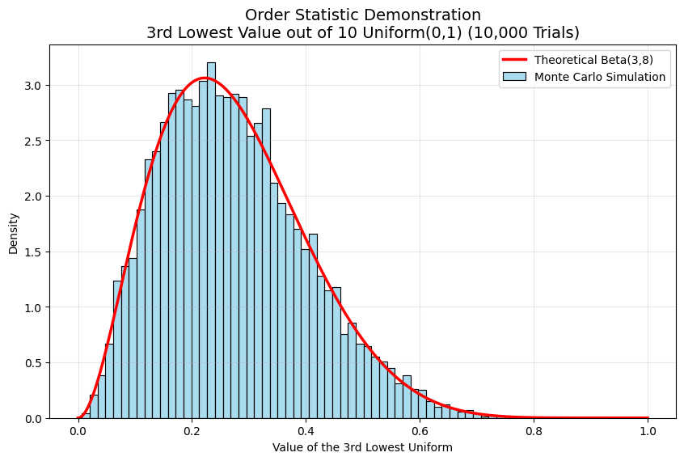

```python
import numpy as np
import matplotlib.pyplot as plt
import seaborn as sns
from scipy.stats import beta
import pandas as pd

# ====================== ORDER STATISTIC DEMO ======================
np.random.seed(42)
n_trials = 10_000
n = 10          # number of uniform rvs per trial
k = 3           # 3rd lowest

# Monte Carlo Simulation
# Generate 10 uniforms per trial, sort, and take the 3rd smallest
samples = np.random.uniform(0, 1, size=(n_trials, n))
third_lowest = np.sort(samples, axis=1)[:, k-1]   # k-1 because of 0-indexing

# Theoretical Beta(3, 8)
alpha = k
beta_param = n + 1 - k

theoretical_mean = beta.mean(alpha, beta_param)
theoretical_std = beta.std(alpha, beta_param)

# Simulation results
sim_mean = third_lowest.mean()
sim_std = third_lowest.std()

# ====================== RESULTS TABLE ======================
data = {
    'Statistic': [
        'Number of Trials',
        'Theoretical Mean (Beta(3,8))',
        'Simulated Mean',
        'Theoretical Std Dev (Beta(3,8))',
        'Simulated Std Dev'
    ],
    'Value': [
        n_trials,
        round(theoretical_mean, 4),
        round(sim_mean, 4),
        round(theoretical_std, 4),
        round(sim_std, 4)
    ]
}

df_results = pd.DataFrame(data)
print("=== 3RD ORDER STATISTIC RESULTS ===")
display(df_results)

# ====================== PLOT ======================
plt.figure(figsize=(10, 6))

# Histogram of simulation
sns.histplot(third_lowest, bins=60, kde=False, color='skyblue',
             edgecolor='black', alpha=0.7, stat="density", label="Monte Carlo Simulation")

# Theoretical Beta density
x = np.linspace(0, 1, 500)
plt.plot(x, beta.pdf(x, alpha, beta_param),
         color='red', linewidth=2.5,
         label=f'Theoretical Beta(3,8)')

plt.title('Order Statistic Demonstration\n3rd Lowest Value out of 10 Uniform(0,1) (10,000 Trials)',
          fontsize=14)
plt.xlabel('Value of the 3rd Lowest Uniform')
plt.ylabel('Density')
plt.legend()
plt.grid(True, alpha=0.3)

plt.savefig('Beta_Order_Statistic.png', dpi=300, bbox_inches='tight')
plt.show()
```

**Figure 2:** Beta Distribution Demonstration

#### Final Thoughts on Beta Distribution Demonstration

The seed is available for reproducibility. **Figure 2** visually depicts how close the simulated results are to the theoretical beta distribution and serves to illustrate how close the expected vs. simulated values are. Due to my first encounter with the beta distribution, I ignored the random seed(42) a few times to understand what was happening with with the graph. **Figure 2** consistently diplayed a distribution that skewed toward the lower end (since we are taking the 3rd lowest value), and the density overlay matched the shape of the histogram closely.

## Question 2 Classic Cars on Exponential to Poisson Distributions

A worldwide distributor of classic cars is analyzing the amount of time it takes before the next customer makes a purchase expecting about 10 customers/purchases per day.

### Memoryless Property, Exponential Distribution, and the Poisson Process

The **Poisson distribution** models the number of times an event occurs over a fixed interval of time or space

When: -Events occur independently -No two events occur at the same instant -The expected rate of occurrence remains constant accross an interval -$\lambda$ is the average number of events per interval (Hanbo, 2026)

The **exponential distribution** models time between events in a Poisson process, assuming that the **rate of occurrence remains constant** over time (Hanbo, 2026).The exponential distribution has a **memoryless property**, which states that the inter-arrival time between events follows an exponential distribution, then the **number of events in a fixed time** follows the **Poisson distribution**.

- If the **time between events** follows an Exponential distribution with $\lambda$,
- then the **number of events in a fixed time period**, such as one day, follows a **Poisson distribution** with $\lambda$.

#### Data for simulation:

- Rate $\lambda = 10$ customers per day
- We simulate the time until each customer arrives using `Exponential(rate=10)`
- We count how many customers arrive in one day (1 unit of time)
- We repeat this for 10,000 days [seems excessive]

**Figure 3** demonstrates the Poisson Distribution with Histogram and a Poisson PMF Overlay.

```
=== POISSON PROCESS SIMULATION RESULTS ===
```

|  | Statistic | Value |
| --- | --- | --- |
| 0 | Number of Trials | 10000.0000 |
| 1 | Theoretical Mean (Poisson λ=10) | 10.0000 |
| 2 | Simulated Mean | 10.0223 |
| 3 | Theoretical Std Dev | 3.1623 |
| 4 | Simulated Std Dev | 3.1473 |

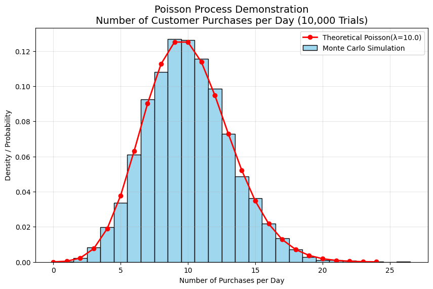

```python
import numpy as np
import matplotlib.pyplot as plt
import seaborn as sns
from scipy.stats import poisson
import pandas as pd

# ====================== POISSON vs EXPONENTIAL DEMO ======================
np.random.seed(42)
n_trials = 10_000
lambda_rate = 10.0   # customers per day

# Simulate number of customers per day using Exponential inter-arrival times
daily_counts = []

for _ in range(n_trials):  # "_" is a dummy variable since we don't need the loop index
    total_time = 0.0
    count = 0

    while True:
        # Generate time until next customer (Exponential)
        inter_arrival = np.random.exponential(scale=1/lambda_rate)
        total_time += inter_arrival

        if total_time > 1.0:        # One full day
            break
        count += 1

    daily_counts.append(count)

daily_counts = np.array(daily_counts)

# Theoretical Poisson(λ=10)
theoretical_mean = lambda_rate
theoretical_std = np.sqrt(lambda_rate)

# Simulation results
sim_mean = daily_counts.mean()
sim_std = daily_counts.std()

# ====================== RESULTS TABLE ======================
data = {
    'Statistic': [
        'Number of Trials',
        'Theoretical Mean (Poisson λ=10)',
        'Simulated Mean',
        'Theoretical Std Dev',
        'Simulated Std Dev'
    ],
    'Value': [
        n_trials,
        round(theoretical_mean, 4),
        round(sim_mean, 4),
        round(theoretical_std, 4),
        round(sim_std, 4)
    ]
}

df_results = pd.DataFrame(data)
print("=== POISSON PROCESS SIMULATION RESULTS ===")
display(df_results)

# ====================== HISTOGRAM ======================
plt.figure(figsize=(10, 6))

# Simulated distribution
sns.histplot(daily_counts, bins=range(0, 25), discrete=True, color='skyblue',
             edgecolor='black', alpha=0.8, stat="density", label="Monte Carlo Simulation")

# Theoretical Poisson Probability Mass Function (PMF)
x = np.arange(0, 25)
plt.plot(x, poisson.pmf(x, mu=lambda_rate), 'ro-', linewidth=2,
         label=f'Theoretical Poisson(λ={lambda_rate})')

plt.title('Poisson Process Demonstration\nNumber of Customer Purchases per Day (10,000 Trials)',
          fontsize=14)
plt.xlabel('Number of Purchases per Day')
plt.ylabel('Density / Probability')
plt.legend()
plt.grid(True, alpha=0.3)

plt.savefig('Poisson_Exponential_Demonstration.png', dpi=300, bbox_inches='tight')
plt.show()
```

**Figure 3:** Poisson Distribution Demonstration

### Final Thoughts on Poisson and Exponential Distributions

This simulation illustrates the relationship between exponential events in a given period (time/space) or the inter-arrival times and the Poisson distribution counting of events in that period. This works when the inter-arrival times are independent and $\lambda$ is exponential.

## Question 3: Life Insurance Policy NPV Simulation

A life insurance company is pricing a new 20-year term life policy for 45-year-old male non-smokers. The time until death is modeled using a **Weibull distribution** with shape parameter $k = 4.5$ and scale parameter $\lambda = 39$ years. Policyholders pay a monthly premium of $115$. If the policyholder dies during the term, beneficiaries receive a lump-sum death benefit of $1,000,000 at the end of that month. Each month there is a 0.3% chance the policy lapses. The company’s cost of capital is 6.5% per year.

### The Weibull Distribution

The Weibull distribution is widely used to model time-to-event data, such as time until failure or death (Hanbo, 2026). Its probability density function (PDF) is given by:

$$ f(x; k, \lambda) = \frac{k}{\lambda} \left( \frac{x}{\lambda} \right)^{k-1} \exp\left[ -\left( \frac{x}{\lambda} \right)^k \right], \quad x \geq 0 $$

where:

- $k$ = **shape parameter** (controls how the hazard rate changes over time)
- $\lambda$ = **scale parameter** (characteristic life)

#### Interpretation of Parameters

- The **shape parameter** $k = 4.5 > 1$ indicates that the **hazard (failure) rate increases over time**. This is realistic for human mortality, as the risk of death rises with advancing age.
- The **scale parameter** $\lambda = 39$ years is known as the **characteristic life**. It has a special mathematical property: approximately **63.2%** of individuals are expected to die by time $x = \lambda$.

#### The Scale Parameter and the Constant $e$

The cumulative distribution function (CDF) of the Weibull distribution at $x = \lambda$ is:

$$ F(\lambda) = 1 - \exp\left[ -\left( \frac{\lambda}{\lambda} \right)^k \right] = 1 - e^{-1} \approx 0.6321 \quad (63.21\%) $$

The constant $e \approx 2.71828$ is **Euler’s number**. The value $e^{-1} \approx 0.367879$ appears naturally in many continuous probability models. Therefore, by age $45 + 39 = 84$, approximately 63.2% of policyholders are expected to have died.

**Specific PDF for this problem:**

$$ f(x; 4.5, 39) = \frac{4.5}{39} \left( \frac{x}{39} \right)^{3.5} \exp\left[ -\left( \frac{x}{39} \right)^{4.5} \right] $$

### Life Insurance Policy NPV Simulation

We model the net present value (NPV) of a 20-year term life insurance policy for a 45-year-old male non-smoker.

**Considerations:**

- Time until death ~ Weibull(shape = 4.5, scale = 39 years)
- Monthly premium = $115
- Death benefit = $1,000,000 (paid at end of month of death)
- Monthly lapse probability = 0.3% (0.003)
- Annual discount rate = 6.5% (monthly rate = 6.5%/12)

For each simulated policyholder, we track monthly cash flows until one of the following occurs:

- Policy lapses
- Policyholder dies
- Policy reaches 20 years (240 months)

```python
import numpy as np
import pandas as pd
import matplotlib.pyplot as plt
import seaborn as sns
from scipy.stats import weibull_min

# ====================== LIFE INSURANCE NPV SIMULATION ======================
np.random.seed(42)
n_trials = 10_000
months = 240                          # 20 years × 12
monthly_premium = 115
death_benefit = 1_000_000
monthly_lapse_prob = 0.003
annual_discount_rate = 0.065
monthly_discount_rate = (1 + annual_discount_rate)**(1/12) - 1


npvs = np.zeros(n_trials)

for trial in range(n_trials):
    # Generate time until death (in years)
    death_time_years = weibull_min.rvs(c=4.5, scale=39)  # Reminder to self: rvs is the method to generate random variates from the distribution.
    death_month = int(np.ceil(death_time_years * 12))   # month in which death occurs

    npv = 0.0
    active = True
    month = 1

    while active and month <= months:
        # Discount factor for cash flows at end of month
        discount_factor = (1 + monthly_discount_rate) ** (-month)

        # Receive premium at the beginning of the month
        npv += monthly_premium * discount_factor

        # Check for lapse this month
        if np.random.rand() < monthly_lapse_prob:
            active = False
            break

        # Check if policyholder dies this month
        if month == death_month:
            npv -= death_benefit * discount_factor
            active = False
            break

        month += 1

    npvs[trial] = npv

# ====================== SUMMARY STATISTICS ======================
mean_npv = npvs.mean()
std_npv = npvs.std()
prob_profit = (npvs > 0).mean()

print("=== SINGLE POLICYHOLDER NPV RESULTS (10,000 trials) ===")
print(f"Mean NPV              : ${mean_npv:,.2f}")
print(f"Standard Deviation    : ${std_npv:,.2f}")
print(f"Probability of Profit : {prob_profit:.1%}")
print(f"Minimum NPV           : ${npvs.min():,.2f}")
print(f"Maximum NPV           : ${npvs.max():,.2f}")
```

```
=== SINGLE POLICYHOLDER NPV RESULTS (10,000 trials) ===
Mean NPV              : $2,661.55
Standard Deviation    : $58,810.56
Probability of Profit : 97.5%
Minimum NPV           : $-731,846.43
Maximum NPV           : $15,653.39
```

### Plot the Histogram of NPVs

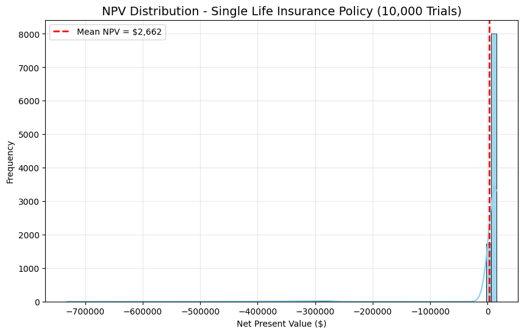

```python
plt.figure(figsize=(10, 6))
sns.histplot(npvs, bins=80, kde=True, color='skyblue', edgecolor='black', alpha=0.8)

plt.title('NPV Distribution - Single Life Insurance Policy (10,000 Trials)', fontsize=14)
plt.xlabel('Net Present Value ($)')
plt.ylabel('Frequency')
plt.axvline(mean_npv, color='red', linestyle='--', linewidth=2,
            label=f'Mean NPV = ${mean_npv:,.0f}')
plt.legend()
plt.grid(True, alpha=0.3)

plt.savefig('Life_Insurance_NPV_Single.png', dpi=300, bbox_inches='tight')
plt.show()
```

**Figure 4**: Net Present Values for Simulated Life Insurance Policies.

#### Interpretation of NPV Results

```python
from scipy import stats

# 95% Confidence Interval
ci_95 = stats.norm.interval(0.95, loc=mean_npv, scale=std_npv/np.sqrt(n_trials))

print(f"95% Confidence Interval for Mean NPV: (${ci_95[0]:,.2f}, ${ci_95[1]:,.2f})")
```

```
95% Confidence Interval for Mean NPV: ($1,508.88, $3,814.21)
```

### Required Number of Trials for a 99% Confidence Interval with Half-Width of $200

The formula for the required sample size to achieve a desired margin of error is:

$$ n = \left( \frac{z_{\alpha/2} \cdot s}{E} \right)^2 $$

where:

- $z_{\alpha/2}$ = z-score for 99% confidence = **2.576** (two-tailed)
- $s$ = sample standard deviation = **$58,810.56**
- $E$ = desired half-width (margin of error) = **$200**

**Calculation:**

$$ n = \left( \frac{2.576 \times 58,810.56}{200} \right)^2 \approx 573,700 $$

**Interpretation**:  
Due to the high variability in NPV (mainly caused by the occasional large death benefit payout), the insurance company would need approximately **573,700 simulation trials** to estimate the mean NPV with a margin of error of ±$200 at the 99% confidence level.

```python
# Correct z-score for 99% confidence interval (two-tailed)
z_99 = stats.norm.ppf(0.995)        # ≈ 2.5758

margin_of_error = 200

required_n = (z_99 * std_npv / margin_of_error) ** 2

print(f"Z-score used (99% CI)     : {z_99:.4f}")
print(f"Standard Deviation        : ${std_npv:,.2f}")
print(f"Required number of trials : {required_n:,.0f}")
```

```
Z-score used (99% CI)     : 2.5758
Standard Deviation        : $58,810.56
Required number of trials : 573,700
```

```python
# Value at which company can be X% sure NPV is at least that value
npv_90 = np.percentile(npvs, 10)   # 90% sure NPV ≥ this value
npv_99 = np.percentile(npvs, 1)    # 99% sure NPV ≥ this value

print(f"The company can be 90% sure NPV is at least: ${npv_90:,.2f}")
print(f"The company can be 99% sure NPV is at least: ${npv_99:,.2f}")
```

```
The company can be 90% sure NPV is at least: $2,887.46
The company can be 99% sure NPV is at least: $-351,218.80
```

### Analyze 1,000 Portfolios

Below is the analysis of total NPV for 1,000 portfolios of 1,000 policies each. The results should indicate the distribution of net present values across the simulated portfolios with a profit similar to the monte carlo simulation in **Figure 4**.

```python
import numpy as np
import pandas as pd

# ====================== 1,000 POLICYHOLDERS PORTFOLIO ======================
np.random.seed(42)
n_portfolio_trials = 1_000      # Number of portfolio simulations
n_policies = 1_000              # Policies per portfolio

portfolio_npvs = []

for trial in range(n_portfolio_trials):
    # Simulate 1,000 independent policies
    policy_npvs = np.zeros(n_policies)

    for p in range(n_policies):
        # --- Same logic as single policy ---
        death_time_years = weibull_min.rvs(c=4.5, scale=39)
        death_month = int(np.ceil(death_time_years * 12))

        npv = 0.0
        active = True
        month = 1

        while active and month <= 240:
            discount_factor = (1 + monthly_discount_rate) ** (-month)
            npv += monthly_premium * discount_factor

            if np.random.rand() < monthly_lapse_prob:
                active = False
                break

            if month == death_month:
                npv -= death_benefit * discount_factor
                active = False
                break

            month += 1

        policy_npvs[p] = npv

    # Total NPV for this portfolio trial
    portfolio_npvs.append(policy_npvs.sum())

portfolio_npvs = np.array(portfolio_npvs)

# ====================== RESULTS ======================
mean_portfolio = portfolio_npvs.mean()
std_portfolio = portfolio_npvs.std()

print("=== 1,000 POLICYHOLDERS PORTFOLIO RESULTS (1,000 trials) ===")
print(f"Mean Total NPV        : ${mean_portfolio:,.2f}")
print(f"Standard Deviation    : ${std_portfolio:,.2f}")
print(f"Probability of Profit : {(portfolio_npvs > 0).mean():.1%}")
print(f"Min Total NPV         : ${portfolio_npvs.min():,.2f}")
print(f"Max Total NPV         : ${portfolio_npvs.max():,.2f}")
```

```
=== 1,000 POLICYHOLDERS PORTFOLIO RESULTS (1,000 trials) ===
Mean Total NPV        : $1,929,795.05
Standard Deviation    : $1,991,174.20
Probability of Profit : 84.2%
Min Total NPV         : $-4,617,953.45
Max Total NPV         : $8,287,057.03
```

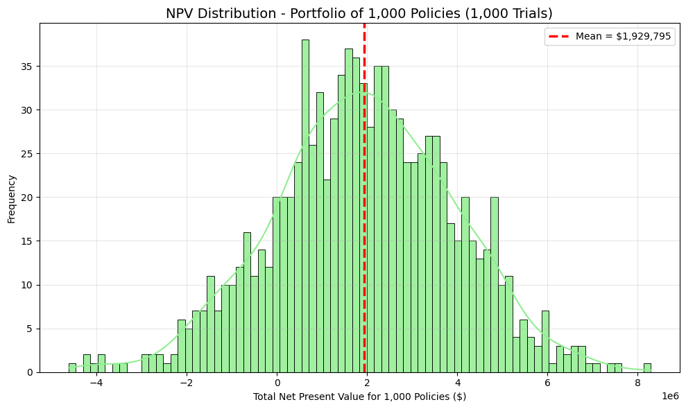

```python
plt.figure(figsize=(10, 6))
sns.histplot(portfolio_npvs, bins=80, kde=True, color='lightgreen', edgecolor='black', alpha=0.85)

plt.title('NPV Distribution - Portfolio of 1,000 Policies (1,000 Trials)', fontsize=14)
plt.xlabel('Total Net Present Value for 1,000 Policies ($)')
plt.ylabel('Frequency')
plt.axvline(mean_portfolio, color='red', linestyle='--', linewidth=2.5,
            label=f'Mean = ${mean_portfolio:,.0f}')
plt.legend()
plt.grid(True, alpha=0.3)
plt.tight_layout()

plt.savefig('Life_Insurance_NPV_1000_Policies.png', dpi=300, bbox_inches='tight')
plt.show()
```

**Figure 5**: Net Present Values for 1,000 Simulated Life Insurance Policies.

**Figure 5** shows the distribution of the total NPVs for 1,000 portfolios of 1,000 policies each. The distribution concentrates close to the mean, and the mean is positive, which indicates that the insurance company can expect to make a profit on the majority of portfolios. Risk still exists, as there are some portfolios with negative NPVs, but the overall profitability is strong due to the large number of policies in each portfolio, which helps to diversify the risk.

```python
print(f"Mean Total NPV          : ${mean_portfolio:,.2f}")
print(f"Standard Deviation      : ${std_portfolio:,.2f}")
print(f"Probability of Profit   : {(portfolio_npvs > 0).mean():.1%}")
```

```
Mean Total NPV          : $1,929,795.05
Standard Deviation      : $1,991,174.20
Probability of Profit   : 84.2%
```

### 95% Confidence Interval for the Mean NPV of a Portfolio of 1,000 Policies

```python
from scipy import stats

ci_95_portfolio = stats.norm.interval(0.95,
                                      loc=mean_portfolio,
                                      scale=std_portfolio/np.sqrt(n_portfolio_trials))

print(f"95% CI for Mean Portfolio NPV: (${ci_95_portfolio[0]:,.2f}, ${ci_95_portfolio[1]:,.2f})")
```

```
95% CI for Mean Portfolio NPV: ($1,806,383.07, $2,053,207.04)
```

We are 95% confident that the true mean NPV of a portfolio of 1,000 policies lies within the confidence interval. The confidence interval is positive which indicates that the insurance company can expect to make a profit on the majority of portfolios.

### Required Number of Trials for a 99% Confidence Interval with Half-Width of $200

Due to diversification, far fewer portfolio simulations are needed to achieve tight confidence intervals compared to analyzing policies individually.

```python
# For the portfolio
z_99 = stats.norm.ppf(0.995)
margin_of_error = 200 * 1000          # $200 per policy × 1,000 policies

required_n_portfolio = (z_99 * std_portfolio / margin_of_error) ** 2

print(f"Required number of portfolio trials: {required_n_portfolio:,.0f}")
```

```
Required number of portfolio trials: 658
```

### Value at Risk (VaR) for a Portfolio of 1,000 Policies

```python
npv_90_port = np.percentile(portfolio_npvs, 10)   # 90% sure total NPV ≥ this
npv_99_port = np.percentile(portfolio_npvs, 1)    # 99% sure total NPV ≥ this

print(f"90% sure total NPV is at least : ${npv_90_port:,.2f}")
print(f"99% sure total NPV is at least : ${npv_99_port:,.2f}")
```

```
90% sure total NPV is at least : $-719,365.56
99% sure total NPV is at least : $-2,842,988.58
```

## References {-}

**Hanbo, Yu.** (2026). *Lecture 3 Analyzing Risk: An Introduction to Modeling Uncertain Inputs*. Boston, MA: Boston University.